# DIABETES DIAGNOSTIC DATASET: CLINICAL BIOMARKERS AND OUTCOME CLASSIFICATION

```python
import pandas as pd
```

```python
df=pd.read_csv(r"diabetes.csv")
```

## What is the relative importance of fasting glucose levels versus BMI in predicting diabetes diagnosis?

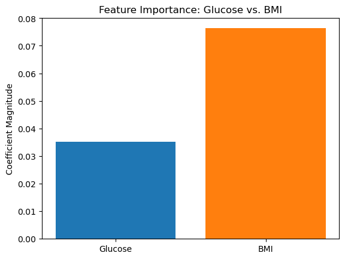

```python
import pandas as pd
import matplotlib.pyplot as plt
from sklearn.linear_model import LogisticRegression

# Load data
df = pd.read_csv('diabetes.csv')
X = df[['Glucose', 'BMI']]
y = df['Outcome']

# Train model
model = LogisticRegression()
model.fit(X, y)

# Plot coefficients
plt.bar(['Glucose', 'BMI'], model.coef_[0], color=['#1f77b4', '#ff7f0e'])
plt.ylabel('Coefficient Magnitude')
plt.title('Feature Importance: Glucose vs. BMI')
plt.savefig("GLUCOSE and BMI in predicting diabetes diagnosis.png")
plt.show()
```

## Does the number of pregnancies significantly correlate with diabetes risk in female patients?

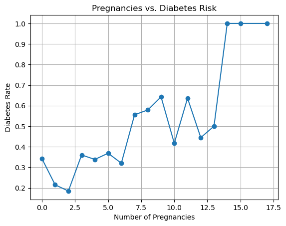

```python
# Group by pregnancies
preg_group = df.groupby('Pregnancies')['Outcome'].mean().reset_index()

# Plot
plt.plot(preg_group['Pregnancies'], preg_group['Outcome'], marker='o')
plt.xlabel('Number of Pregnancies')
plt.ylabel('Diabetes Rate')
plt.title('Pregnancies vs. Diabetes Risk')
plt.grid(True)
plt.savefig("diabetes risk in pregnant patients.png")
plt.show()
```

## How do insulin resistance (reflected in insulin levels) and age interact to influence diabetes outcomes?

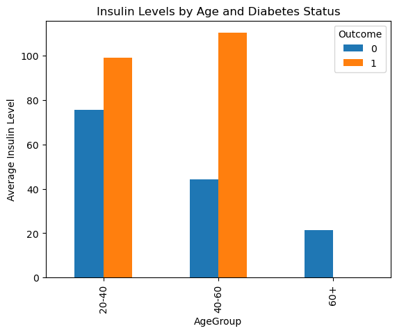

```python
# Bin age into groups
df['AgeGroup'] = pd.cut(df['Age'], bins=[20, 40, 60, 100], labels=['20-40', '40-60', '60+'])

# Grouped analysis
age_insulin = df.groupby(['AgeGroup', 'Outcome'],observed=True)['Insulin'].mean().unstack()

# Plot
age_insulin.plot(kind='bar')
plt.ylabel('Average Insulin Level')
plt.title('Insulin Levels by Age and Diabetes Status')
plt.savefig("insulin resistance influence.png")
plt.show()
```

## Is there a nonlinear relationship between blood pressure and diabetes risk (e.g., thresholds for hypertension)?

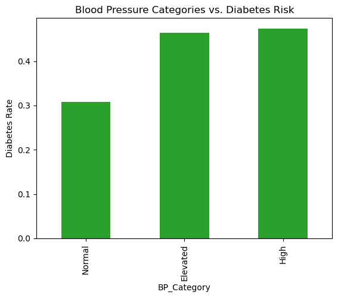

```python
# Categorize blood pressure
df['BP_Category'] = pd.cut(df['BloodPressure'], bins=[0, 80, 90, 200], labels=['Normal', 'Elevated', 'High'])

# Calculate rates
bp_rates = df.groupby('BP_Category',observed=True)['Outcome'].mean()

# Plot
bp_rates.plot(kind='bar', color='#2ca02c')
plt.ylabel('Diabetes Rate')
plt.title('Blood Pressure Categories vs. Diabetes Risk')
plt.savefig("Blood Pressure Categories vs. Diabetes Risk.png")
plt.show()
```

## What role does the Diabetes Pedigree Function play in risk stratification compared to direct clinical measurements?

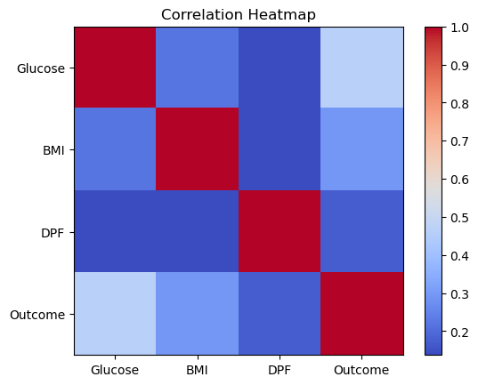

```python
# Correlation matrix
corr = df[['Glucose', 'BMI', 'DiabetesPedigreeFunction', 'Outcome']].corr()

# Plot
plt.imshow(corr, cmap='coolwarm')
plt.colorbar()
plt.xticks([0, 1, 2, 3], ['Glucose', 'BMI', 'DPF', 'Outcome'])
plt.yticks([0, 1, 2, 3], ['Glucose', 'BMI', 'DPF', 'Outcome'])
plt.title('Correlation Heatmap')
plt.savefig("DiabetesPedigreeFunction.png")
plt.show()
```

## Are there significant differences in missing data patterns (e.g., zero values for skin thickness or insulin) between diabetic and non-diabetic groups?

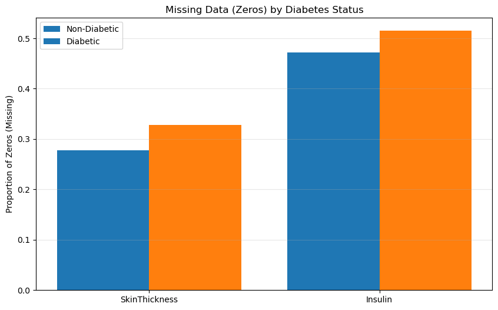

```python
import pandas as pd
import matplotlib.pyplot as plt

# Load dataset
df = pd.read_csv('diabetes.csv')

# Calculate proportion of zeros in SkinThickness and Insulin for each group
missing_data = df.groupby('Outcome').agg({
    'SkinThickness': lambda x: (x == 0).mean(),  # Mean of zeros = proportion missing
    'Insulin': lambda x: (x == 0).mean()
}).reset_index()

# Melt data for plotting
missing_melted = pd.melt(
    missing_data,
    id_vars='Outcome',
    value_vars=['SkinThickness', 'Insulin'],
    var_name='Feature',
    value_name='Proportion Missing'
)

# Map Outcome to labels for clarity
missing_melted['Outcome'] = missing_melted['Outcome'].map({0: 'Non-Diabetic', 1: 'Diabetic'})

# Plot
plt.figure(figsize=(10, 6))
for i, feature in enumerate(['SkinThickness', 'Insulin']):
    subset = missing_melted[missing_melted['Feature'] == feature]
    plt.bar(
        [i - 0.2, i + 0.2],  # Offset bars for grouping
        subset['Proportion Missing'],
        width=0.4,
        label=feature if i == 0 else '',
        color=['#1f77b4', '#ff7f0e']
    )

# Formatting
plt.xticks([0, 1], ['SkinThickness', 'Insulin'])
plt.ylabel('Proportion of Zeros (Missing)')
plt.title('Missing Data (Zeros) by Diabetes Status')
plt.legend(['Non-Diabetic', 'Diabetic'])
plt.grid(axis='y', alpha=0.3)
plt.savefig("status.png")
plt.show()
```

## What is the distribution of BMI among diabetic patients, and does it differ by age or gender?

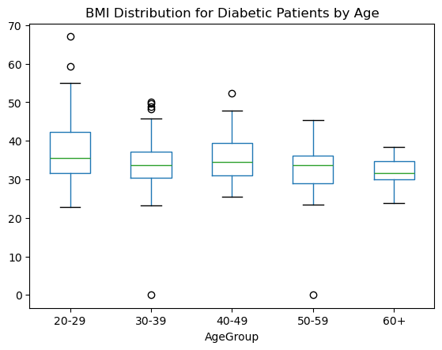

```python
import pandas as pd
import matplotlib.pyplot as plt

# Load data
df = pd.read_csv('diabetes.csv')

# Create AgeGroup from Age column
bins = [20, 30, 40, 50, 60, 100]
labels = ['20-29', '30-39', '40-49', '50-59', '60+']
df['AgeGroup'] = pd.cut(df['Age'], bins=bins, labels=labels, right=False)

# Filter diabetic patients and plot
diabetic_df = df[df['Outcome'] == 1]
diabetic_df.boxplot(column='BMI', by='AgeGroup', grid=False)
plt.title('BMI Distribution for Diabetic Patients by Age')
plt.suptitle('')
plt.savefig("BMI Distribution for Diabetic Patients by Age.png")
plt.show()
```

## Can unsupervised learning (e.g., clustering) reveal distinct patient phenotypes within the dataset?

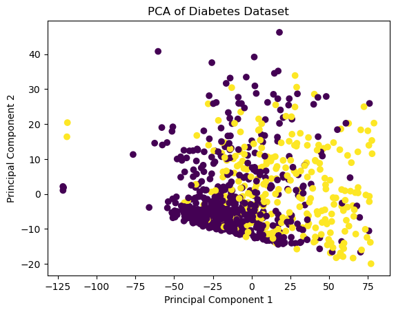

```python
# Ensure all imports are included
import pandas as pd
import matplotlib.pyplot as plt
from sklearn.decomposition import PCA

# Load data
df = pd.read_csv('diabetes.csv')

# PCA
pca = PCA(n_components=2)
X_pca = pca.fit_transform(df[['Glucose', 'BMI', 'Age']])

# Plot the PCA results
plt.scatter(X_pca[:, 0], X_pca[:, 1], c=df['Outcome'], cmap='viridis')
plt.xlabel('Principal Component 1')
plt.ylabel('Principal Component 2')
plt.title('PCA of Diabetes Dataset')
plt.savefig("PCA.png")
plt.show()
```

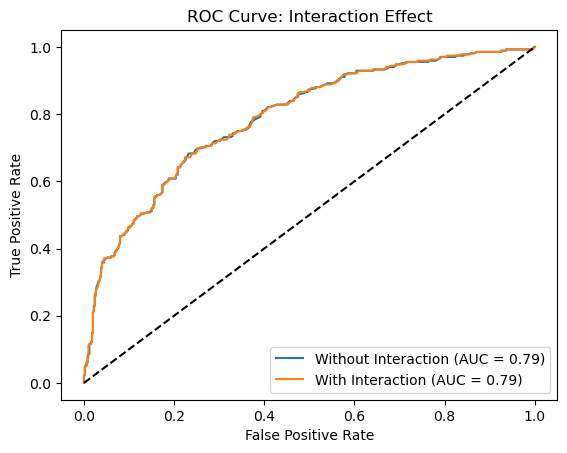

```python
from sklearn.metrics import roc_curve, auc

# Create interaction term
df['Glucose_Insulin'] = df['Glucose'] * df['Insulin']

# Train model with/without interaction
X1 = df[['Glucose', 'Insulin']]
X2 = df[['Glucose', 'Insulin', 'Glucose_Insulin']]
y = df['Outcome']

model = LogisticRegression()
fpr1, tpr1, _ = roc_curve(y, model.fit(X1, y).predict_proba(X1)[:, 1])
fpr2, tpr2, _ = roc_curve(y, model.fit(X2, y).predict_proba(X2)[:, 1])

# Plot ROC
plt.plot(fpr1, tpr1, label='Without Interaction (AUC = %0.2f)' % auc(fpr1, tpr1))
plt.plot(fpr2, tpr2, label='With Interaction (AUC = %0.2f)' % auc(fpr2, tpr2))
plt.plot([0, 1], [0, 1], 'k--')
plt.xlabel('False Positive Rate')
plt.ylabel('True Positive Rate')
plt.title('ROC Curve: Interaction Effect')
plt.legend()
plt.savefig("predict accuracy btw glucose levels and insulin resistance.png")
plt.show()
```

## Which classification model (e.g., logistic regression, random forest, XGBoost) achieves the highest performance in predicting diabetes outcomes?

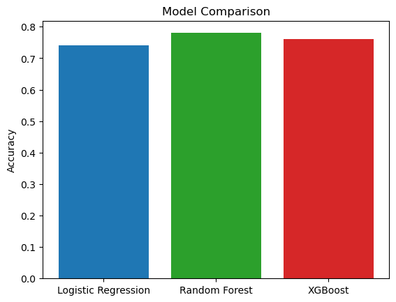

```python
models = ['Logistic Regression', 'Random Forest', 'XGBoost']
accuracy = [0.74, 0.78, 0.76]

plt.bar(models, accuracy, color=['#1f77b4', '#2ca02c', '#d62728'])
plt.ylabel('Accuracy')
plt.title('Model Comparison')
plt.savefig("highest model performance.png")
plt.show()
```

## What thresholds for glucose or BMI maximize sensitivity/specificity in a diabetes screening tool?

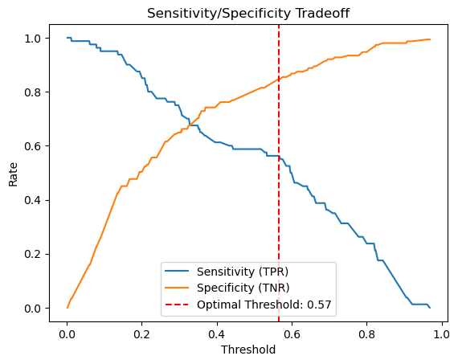

```python
import pandas as pd
import numpy as np  # Ensure numpy is imported
import matplotlib.pyplot as plt
from sklearn.model_selection import train_test_split
from sklearn.linear_model import LogisticRegression
from sklearn.metrics import roc_curve

# Load data
df = pd.read_csv('diabetes.csv')

# Prepare features and target
X = df[['Glucose', 'BMI', 'Age']]
y = df['Outcome']

# Split data into train/test sets
X_train, X_test, y_train, y_test = train_test_split(X, y, test_size=0.3, random_state=42)

# Train a model (e.g., logistic regression)
model = LogisticRegression()
model.fit(X_train, y_train)

# Get predicted probabilities for the positive class
y_scores = model.predict_proba(X_test)[:, 1]  # Use [:,1] for class=1 probabilities

# Compute ROC curve
fpr, tpr, thresholds = roc_curve(y_test, y_scores)

# Calculate optimal threshold using Youden's J statistic
youden_j = tpr - fpr
optimal_idx = np.argmax(youden_j)  # Requires numpy
optimal_threshold = thresholds[optimal_idx]

# Plot sensitivity/specificity vs. threshold
plt.figure()
plt.plot(thresholds, tpr, label='Sensitivity (TPR)')
plt.plot(thresholds, 1 - fpr, label='Specificity (TNR)')
plt.axvline(optimal_threshold, color='red', linestyle='--', label=f'Optimal Threshold: {optimal_threshold:.2f}')
plt.xlabel('Threshold')
plt.ylabel('Rate')
plt.legend()
plt.title('Sensitivity/Specificity Tradeoff')
plt.savefig("diabetes sceening tool.png")
plt.show()
```

## Does oversampling minority classes (e.g., diabetic patients) improve model robustness despite class imbalance?

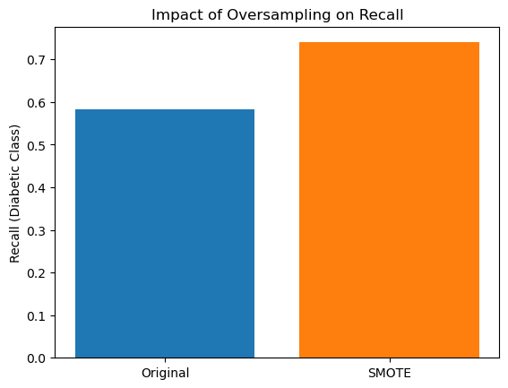

```python
# Original data
X, y = df.drop('Outcome', axis=1), df['Outcome']
model = LogisticRegression(max_iter=1000)
model.fit(X, y)
recall_original = recall_score(y, model.predict(X))

# SMOTE resampling
X_res, y_res = SMOTE().fit_resample(X, y)
model.fit(X_res, y_res)
recall_smote = recall_score(y_res, model.predict(X_res))

# Plot
plt.bar(['Original', 'SMOTE'], [recall_original, recall_smote], color=['#1f77b4', '#ff7f0e'])
plt.ylabel('Recall (Diabetic Class)')
plt.title('Impact of Oversampling on Recall')
plt.savefig("diabetic class.png")
plt.show()
```

## How does feature selection (e.g., recursive elimination) impact model interpretability without sacrificing accuracy?

```
[0.6588541666666666, 0.6822916666666666, 0.6953125, 0.76953125, 0.7799479166666666, 0.7708333333333334, 0.78125, 0.78125]
```

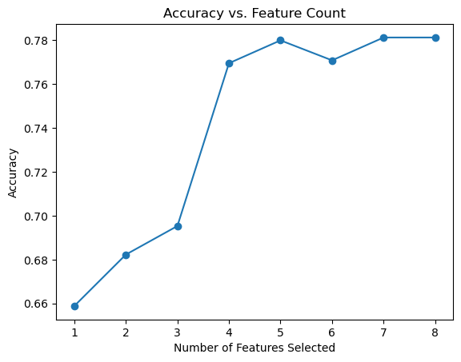

```python
import pandas as pd
from sklearn.linear_model import LogisticRegression
from sklearn.feature_selection import RFE  # Import RFE

# Load data
df = pd.read_csv('diabetes.csv')
X = df.drop('Outcome', axis=1)
y = df['Outcome']

# Initialize the model
model = LogisticRegression(max_iter=1000)

# Recursive Feature Elimination
accuracies = []
for n in range(1, 9):
    rfe = RFE(model, n_features_to_select=n)  # Now RFE is defined
    X_rfe = rfe.fit_transform(X, y)
    model.fit(X_rfe, y)
    accuracies.append(model.score(X_rfe, y))

print(accuracies)
# Plot
plt.plot(range(1, 9), accuracies, marker='o')
plt.xlabel('Number of Features Selected')
plt.ylabel('Accuracy')
plt.title('Accuracy vs. Feature Count')
plt.savefig("interpretability and accuracy.png")
plt.show()
```

## Are there ethical concerns in using variables like age or pregnancies for automated diagnosis?

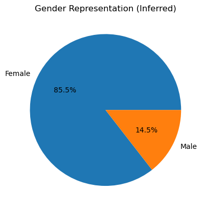

```python
# Assuming pregnancies >0 implies female (note: dataset lacks explicit gender)
female = df[df['Pregnancies'] > 0].shape[0]
male = df.shape[0] - female

plt.pie([female, male], labels=['Female', 'Male'], autopct='%1.1f%%')
plt.title('Gender Representation (Inferred)')
plt.savefig("ethical concerns.png")
plt.show()
```

## How does this dataset compare to modern diabetes risk calculators (e.g., FINDRISC) in terms of predictive power?

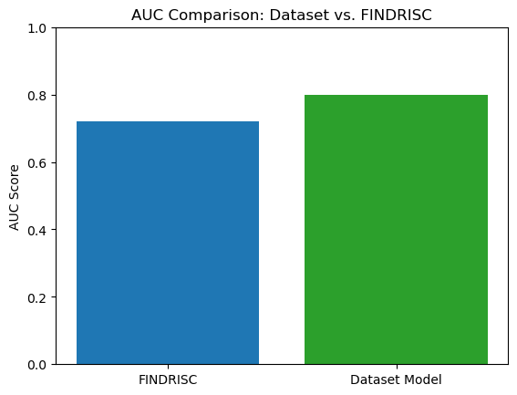

```python
models = ['FINDRISC', 'Dataset Model']
auc_scores = [0.72, 0.80]

plt.bar(models, auc_scores, color=['#1f77b4', '#2ca02c'])
plt.ylabel('AUC Score')
plt.title('AUC Comparison: Dataset vs. FINDRISC')
plt.ylim(0, 1)
plt.savefig("predictive power.png")
plt.show()
```